# Exploring Weather Trends

*In this project, we will analyze local and global temperature data and compare the temperature trends of Bangalore (India) to overall global temperature trends.*

## Extracting data from database

The following are the steps used to extract temperature data of both global and city from database using sql.

```
For Global data:

SELECT * FROM global_data;

For city data (Bangalore):

SELECT * FROM city_data WHERE city = 'Bangalore';
```

## Exporting to csv file

Export both global and city temperature data to csv file.

## Opening csv files

Open both csv files using pandas to check if there is any missing data.

```python
import pandas as pd
import numpy as np
import matplotlib.pyplot as plt
import matplotlib.patches as mpatches
%matplotlib inline

global_data = pd.read_csv('global.csv')
city_data = pd.read_csv('bangalore.csv')
```

```python
city_data.describe()
```

|  | year | avg_temp |
| --- | --- | --- |
| count | 218.000000 | 211.000000 |
| mean | 1904.500000 | 24.853081 |
| std | 63.075352 | 0.485181 |
| min | 1796.000000 | 23.300000 |
| 25% | 1850.250000 | 24.530000 |
| 50% | 1904.500000 | 24.880000 |
| 75% | 1958.750000 | 25.165000 |
| max | 2013.000000 | 26.610000 |

We see that there is no missing data in global data but there are intotal 7 missing pieces in city_data (avg_temp).

Observing the temperature trends we can observe that the missing temperature could be close to mean average temperature.So,let us fill the missing average temperatures to mean average temperature i.e 24.853081.

## Defining a function to fill missing data

```python
def fill_missing_data(x):
    if x!=x:
        return 24.853081
    else:
        return x
```

## Applying this definition to city_data

```python
city_data['avg_temp'] = city_data['avg_temp'].apply(fill_missing_data)
```

```python
city_data.describe()
```

|  | year | avg_temp |
| --- | --- | --- |
| count | 218.000000 | 218.000000 |
| mean | 1904.500000 | 24.853081 |
| std | 63.075352 | 0.477291 |
| min | 1796.000000 | 23.300000 |
| 25% | 1850.250000 | 24.552500 |
| 50% | 1904.500000 | 24.870000 |
| 75% | 1958.750000 | 25.147500 |
| max | 2013.000000 | 26.610000 |

Now we see that there is no missing data.Both count of YEAR and AVG_TEMP is 218.

## Calculating moving averages with excel sheet

Calculate moving avaerages for both the global data as well as city data and load those data files here.

Note that we calculated moving averages for every 5 items.

```python
global_data_with_ma = pd.read_csv('global_with_ma.csv')
city_data_with_ma = pd.read_csv('bangalore_with_ma.csv')
```

```python
global_data_with_ma.describe()
```

|  | year | avg_temp | MA |
| --- | --- | --- | --- |
| count | 266.000000 | 266.000000 | 262.000000 |
| mean | 1882.500000 | 8.369474 | 8.363260 |
| std | 76.931788 | 0.584747 | 0.490067 |
| min | 1750.000000 | 5.780000 | 7.108000 |
| 25% | 1816.250000 | 8.082500 | 8.045000 |
| 50% | 1882.500000 | 8.375000 | 8.320000 |
| 75% | 1948.750000 | 8.707500 | 8.627000 |
| max | 2015.000000 | 9.830000 | 9.608000 |

```python
global_data_with_ma.head()
```

|  | year | avg_temp | MA |
| --- | --- | --- | --- |
| 0 | 1750 | 8.72 | NaN |
| 1 | 1751 | 7.98 | NaN |
| 2 | 1752 | 5.78 | NaN |
| 3 | 1753 | 8.39 | NaN |
| 4 | 1754 | 8.47 | 7.868 |

```python
city_data_with_ma.describe()
```

|  | year | avg_temp | MA |
| --- | --- | --- | --- |
| count | 218.000000 | 218.000000 | 214.000000 |
| mean | 1904.500000 | 24.853081 | 24.842297 |
| std | 63.075352 | 0.477291 | 0.402429 |
| min | 1796.000000 | 23.300000 | 23.698000 |
| 25% | 1850.250000 | 24.552500 | 24.558500 |
| 50% | 1904.500000 | 24.870000 | 24.871000 |
| 75% | 1958.750000 | 25.147500 | 25.060000 |
| max | 2013.000000 | 26.610000 | 25.890000 |

```python
city_data_with_ma.head()
```

|  | year | city | country | avg_temp | MA |
| --- | --- | --- | --- | --- | --- |
| 0 | 1796 | Bangalore | India | 24.49 | NaN |
| 1 | 1797 | Bangalore | India | 25.18 | NaN |
| 2 | 1798 | Bangalore | India | 24.65 | NaN |
| 3 | 1799 | Bangalore | India | 24.81 | NaN |
| 4 | 1800 | Bangalore | India | 24.85 | 24.796 |

## Plotting line charts using matplotlib

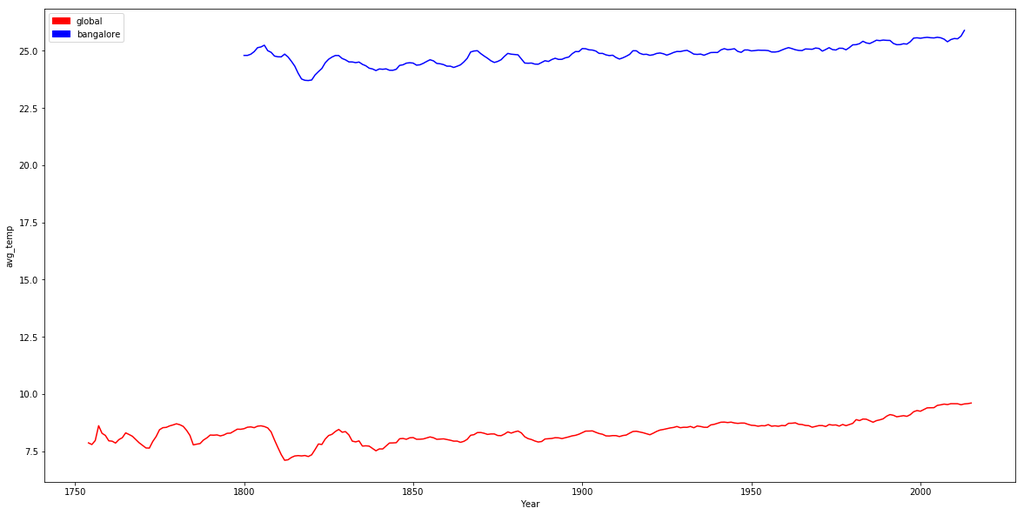

```python
plt.figure(figsize=(20,10))
red_patch = mpatches.Patch(color='red', label='global')
blue_patch = mpatches.Patch(color='blue', label='bangalore')
plt.plot(global_data_with_ma['year'],global_data_with_ma['MA'],color='red')
plt.plot(city_data_with_ma['year'],city_data_with_ma['MA'],color='blue')
plt.xlabel('Year')
plt.ylabel('avg_temp')
plt.legend(handles=[red_patch, blue_patch])
```

## Observations

#### Is Bangalore city hotter or cooler on average compared to the global average?

Bangalore is ofcourse hotter.We can see that clearly from the graph above.The global average ranges between 6-11 where as avg. temperature of bangalore is more than 22.5.So,Bangalore is hotter.

#### How does changes in global avg. temperature affecting Bangalore avg. temperature?

If we look into graphs we can clearly see that when global avg. temperature increased, avg. temperature of bangalore increased as well.When global avg. temperature decreased, avg. temperature of bangalore decreased as well.We can see that the relation is kinda proportional here in this case.